# Lab Session 8

Lidia Montero, Josep Anton Sanchez & Jordi Cortes

November 2018

# Children Ever Born: ceb data set

### Data

*id*: identificador de la regió

*dur*: durada del matrimoni (6 categories)

*mean*: mitjana de fills

*var*: variança de fills

*n*: número de dones enquestades

*y*: número total de fills

Les dades estan agrupades, cada fila no respon a una dona, sió a una combinació de categories, donantnos per a cada fila el nombre de dones enquestades i el nombre total de fills (var resposta).

S’ha pogut agrupar perquè no hi ha cap var numèrica. Només tenim 3 vars categòriques, i com que cada una te, respectivaament, 6,4 i 3 nivells, existeicen 72 (6*4*3) combinacions posibles (files a la bbdd).

Al estar agrupades, el nombre de dones enquestades per a cada categoria no serà el mateix per a totes, llavors la taxa de fills (var resposta), variarà segons el n de la fila (combinació) estem mirant. ALERTA!

La mida de cada registre (n), el paper que juga aquesta n es el offset: correspon a una variable que justificarà que en una situació el valor esperat de la resposta sigui alt (offset: variable explicativa que en realitat no te beta)

- Dades desagregades:

log(lambda_i)=beta_0 + (beta_1 * x_1) …

- Dades agregades(el nostre cas):

log(lambda_i)=log(n) + beta_0 + (beta_1 * x_1) … on log(n) = OFFSET

`ex.` Si Y: nombre de casos en el que pasa X cosa; la taxa (lambda) vindrà donada per l’offset, el nombre de la població, que te en compte el nombre d’individus que hi ha en aquell registre.

```r
options(warn = -1)
library(effects,warn.conflicts = TRUE,quietly=TRUE)
library(MASS,warn.conflicts = TRUE,quietly=TRUE)
library(AER,warn.conflicts = TRUE,quietly=TRUE)
library(car,warn.conflicts = TRUE,quietly=TRUE)
library(lmtest,warn.conflicts = TRUE,quietly=TRUE)
load("ceb.RData")
head(ceb)
```

```
##   id dur   res  educ mean  var  n  y
## 1  1 0-4  Suva  none 0.50 1.14  8  4
## 2  2 0-4  Suva lower 1.14 0.73 21 24
## 3  3 0-4  Suva upper 0.90 0.67 42 38
## 4  4 0-4  Suva  sec+ 0.73 0.48 51 37
## 5  5 0-4 urban  none 1.17 1.06 12 14
## 6  6 0-4 urban lower 0.85 1.59 27 23
```

```r
summary(ceb)
```

```
##        id           dur        res        educ         mean
##  Min.   : 1.00   0-4  :12   Suva :24   none :18   Min.   :0.500
##  1st Qu.:18.25   5-9  :12   urban:23   lower:18   1st Qu.:2.252
##  Median :35.50   10-14:12   rural:23   upper:18   Median :3.645
##  Mean   :35.54   15-19:12              sec+ :16   Mean   :3.696
##  3rd Qu.:52.75   20-24:12                         3rd Qu.:5.263
##  Max.   :71.00   25-29:10                         Max.   :7.810
##       var                n                y
##  Min.   : 0.0000   Min.   :  1.00   Min.   :   2.0
##  1st Qu.: 0.9325   1st Qu.: 13.00   1st Qu.:  38.0
##  Median : 1.9450   Median : 24.50   Median :  77.5
##  Mean   : 3.2960   Mean   : 38.24   Mean   : 151.5
##  3rd Qu.: 4.2925   3rd Qu.: 47.00   3rd Qu.: 151.5
##  Max.   :12.6000   Max.   :195.00   Max.   :1459.0
```

**COMENTARIS head(ceb)**

Fila 1, 8 dones amb aquelles característiques sumen 4 fills en total. No sabem quants en tenen 1 o cap, sinó que en total, aquestes 8 sumen 4.

Ens interessa la taxa esperada de fills per dones.

Les dades estan agragades per regió.

# Models

### Model nul

```r
ceb$logn <- log(ceb$n)  # creem offset =log(n)
m0 <- glm(y ~ offset(ceb$logn), family=poisson, data=ceb)
summary(m0)
```

```
##
## Call:
## glm(formula = y ~ offset(ceb$logn), family = poisson, data = ceb)
##
## Deviance Residuals:
##      Min        1Q    Median        3Q       Max
## -18.6368   -4.4774   -0.8548    2.5292   21.9744
##
## Coefficients:
##             Estimate Std. Error z value Pr(>|z|)
## (Intercept) 1.376346   0.009712   141.7   <2e-16 ***
## ---
## Signif. codes:  0 '***' 0.001 '**' 0.01 '*' 0.05 '.' 0.1 ' ' 1
##
## (Dispersion parameter for poisson family taken to be 1)
##
##     Null deviance: 3731.9  on 69  degrees of freedom
## Residual deviance: 3731.9  on 69  degrees of freedom
## AIC: 4163.3
##
## Number of Fisher Scoring iterations: 5
```

L’offset no te ningun paràmetre, la constant beta_0 (intercept) és la que ens dira el nombre esperat de fills per dona.

En aquest model nul estem suposant que independentment dels factors (vars explicatives), la taxa de fills esperada és la mateixa per a totes les dones.

Té màxima deviança. Té 69 g.ll perquè en total hi ha 70 files (tot i que hi ha 72 combinacions, hi ha 2 que no es donen). si ajustem el model amb nomes una constant gastem 1 grau de llibertat 70-1=69.

**Seria assumible aquest model?**

És a dir, és compatible amb les dades observades, i podem dir que podem suposar ue la taxa sempre serà aquesta independentment del nombre d’anys de matrimoni etc?

La deviança es molt mes gran que el graus de llibertat, per tant podem rebutjar la ho de que el model s’ajusti a les dades i que la taxa sigui una constant.

*——*

### Models amb una predictora

```r
m1.dur <- glm(y ~ offset(ceb$logn) + dur, family=poisson, data=ceb)
summary(m1.dur)
```

```
##
## Call:
## glm(formula = y ~ offset(ceb$logn) + dur, family = poisson, data = ceb)
##
## Deviance Residuals:
##     Min       1Q   Median       3Q      Max
## -3.5590  -1.4690  -0.5489   0.6028   4.0074
##
## Coefficients:
##             Estimate Std. Error z value Pr(>|z|)
## (Intercept) -0.10360    0.04415  -2.347   0.0189 *
## dur5-9       1.04489    0.05240  19.942   <2e-16 ***
## dur10-14     1.44495    0.05024  28.761   <2e-16 ***
## dur15-19     1.70676    0.04975  34.308   <2e-16 ***
## dur20-24     1.87747    0.04965  37.815   <2e-16 ***
## dur25-29     2.07886    0.04751  43.759   <2e-16 ***
## ---
## Signif. codes:  0 '***' 0.001 '**' 0.01 '*' 0.05 '.' 0.1 ' ' 1
##
## (Dispersion parameter for poisson family taken to be 1)
##
##     Null deviance: 3731.85  on 69  degrees of freedom
## Residual deviance:  166.07  on 64  degrees of freedom
## AIC: 607.55
##
## Number of Fisher Scoring iterations: 4
```

```r
m1.res <- glm(y ~ offset(ceb$logn) + res, family=poisson, data=ceb)
summary(m1.res)
```

```
##
## Call:
## glm(formula = y ~ offset(ceb$logn) + res, family = poisson, data = ceb)
##
## Deviance Residuals:
##      Min        1Q    Median        3Q       Max
## -19.6141   -4.1326   -0.3872    3.2787   20.1998
##
## Coefficients:
##             Estimate Std. Error z value Pr(>|z|)
## (Intercept)  1.20460    0.02499  48.199  < 2e-16 ***
## resurban     0.14429    0.03245   4.447 8.72e-06 ***
## resrural     0.22806    0.02783   8.194 2.52e-16 ***
## ---
## Signif. codes:  0 '***' 0.001 '**' 0.01 '*' 0.05 '.' 0.1 ' ' 1
##
## (Dispersion parameter for poisson family taken to be 1)
##
##     Null deviance: 3731.9  on 69  degrees of freedom
## Residual deviance: 3659.3  on 67  degrees of freedom
## AIC: 4094.8
##
## Number of Fisher Scoring iterations: 5
```

```r
m1.educ <- glm(y ~ offset(ceb$logn) + educ, family=poisson, data=ceb)
summary(m1.educ)
```

```
##
## Call:
## glm(formula = y ~ offset(ceb$logn) + educ, family = poisson,
##     data = ceb)
##
## Deviance Residuals:
##      Min        1Q    Median        3Q       Max
## -19.2860   -3.0839    0.7429    3.8563   13.1507
##
## Coefficients:
##             Estimate Std. Error z value Pr(>|z|)
## (Intercept)  1.64728    0.01469  112.11   <2e-16 ***
## educlower   -0.21179    0.02168   -9.77   <2e-16 ***
## educupper   -0.61605    0.02886  -21.35   <2e-16 ***
## educsec+    -1.22468    0.05141  -23.82   <2e-16 ***
## ---
## Signif. codes:  0 '***' 0.001 '**' 0.01 '*' 0.05 '.' 0.1 ' ' 1
##
## (Dispersion parameter for poisson family taken to be 1)
##
##     Null deviance: 3731.9  on 69  degrees of freedom
## Residual deviance: 2661.0  on 66  degrees of freedom
## AIC: 3098.5
##
## Number of Fisher Scoring iterations: 5
```

La variable més rellevant, a priori, sembla la durada de matrimoni ja queté una deviança residual i un AIC menor de la resta. Les significacions en totes les variables del diferents models podrien venir explicades per no condiderar la sobredispersió.

En cap cas hem obtingut un model satisfactori (el valor de la deviança no està per sota de l’umbral segons el grau de llibertats que tenen com per considferarlo un model correcte).

*——*

### Models additius

```r
m2.DR <- glm(y ~ offset(ceb$logn) + dur + res, family=poisson, data=ceb)
summary(m2.DR)
```

```
##
## Call:
## glm(formula = y ~ offset(ceb$logn) + dur + res, family = poisson,
##     data = ceb)
##
## Deviance Residuals:
##     Min       1Q   Median       3Q      Max
## -2.7517  -1.1748  -0.3193   0.8237   4.1255
##
## Coefficients:
##             Estimate Std. Error z value Pr(>|z|)
## (Intercept) -0.23476    0.04935  -4.757 1.96e-06 ***
## dur5-9       1.03861    0.05241  19.818  < 2e-16 ***
## dur10-14     1.43504    0.05026  28.552  < 2e-16 ***
## dur15-19     1.69813    0.04976  34.124  < 2e-16 ***
## dur20-24     1.86753    0.04967  37.596  < 2e-16 ***
## dur25-29     2.07380    0.04751  43.647  < 2e-16 ***
## resurban     0.11895    0.03246   3.664 0.000248 ***
## resrural     0.18192    0.02785   6.532 6.50e-11 ***
## ---
## Signif. codes:  0 '***' 0.001 '**' 0.01 '*' 0.05 '.' 0.1 ' ' 1
##
## (Dispersion parameter for poisson family taken to be 1)
##
##     Null deviance: 3731.85  on 69  degrees of freedom
## Residual deviance:  120.68  on 62  degrees of freedom
## AIC: 566.16
##
## Number of Fisher Scoring iterations: 4
```

```r
m2.DE <- glm(y ~ offset(ceb$logn) + dur + educ, family=poisson, data=ceb)
summary(m2.DE)
```

```
##
## Call:
## glm(formula = y ~ offset(ceb$logn) + dur + educ, family = poisson,
##     data = ceb)
##
## Deviance Residuals:
##     Min       1Q   Median       3Q      Max
## -2.4186  -1.1015  -0.1535   0.6354   3.5324
##
## Coefficients:
##             Estimate Std. Error z value Pr(>|z|)
## (Intercept)  0.01813    0.04857   0.373    0.709
## dur5-9       0.99645    0.05274  18.895  < 2e-16 ***
## dur10-14     1.36860    0.05105  26.809  < 2e-16 ***
## dur15-19     1.60779    0.05114  31.439  < 2e-16 ***
## dur20-24     1.77848    0.05118  34.751  < 2e-16 ***
## dur25-29     1.96267    0.04989  39.341  < 2e-16 ***
## educlower    0.01057    0.02237   0.472    0.637
## educupper   -0.12287    0.03045  -4.035 5.45e-05 ***
## educsec+    -0.36026    0.05408  -6.661 2.72e-11 ***
## ---
## Signif. codes:  0 '***' 0.001 '**' 0.01 '*' 0.05 '.' 0.1 ' ' 1
##
## (Dispersion parameter for poisson family taken to be 1)
##
##     Null deviance: 3731.85  on 69  degrees of freedom
## Residual deviance:  100.19  on 61  degrees of freedom
## AIC: 547.67
##
## Number of Fisher Scoring iterations: 4
```

```r
m2.RE <- glm(y ~ offset(ceb$logn) + res + educ ,family=poisson, data=ceb)
summary(m2.RE)
```

```
##
## Call:
## glm(formula = y ~ offset(ceb$logn) + res + educ, family = poisson,
##     data = ceb)
##
## Deviance Residuals:
##     Min       1Q   Median       3Q      Max
## -19.196   -3.419    1.068    3.852   13.226
##
## Coefficients:
##             Estimate Std. Error z value Pr(>|z|)
## (Intercept)  1.58469    0.02832  55.951  < 2e-16 ***
## resurban     0.12216    0.03247   3.762 0.000168 ***
## resrural     0.06038    0.02820   2.141 0.032252 *
## educlower   -0.21482    0.02183  -9.840  < 2e-16 ***
## educupper   -0.61918    0.02916 -21.231  < 2e-16 ***
## educsec+    -1.22427    0.05217 -23.467  < 2e-16 ***
## ---
## Signif. codes:  0 '***' 0.001 '**' 0.01 '*' 0.05 '.' 0.1 ' ' 1
##
## (Dispersion parameter for poisson family taken to be 1)
##
##     Null deviance: 3731.9  on 69  degrees of freedom
## Residual deviance: 2646.5  on 64  degrees of freedom
## AIC: 3088
##
## Number of Fisher Scoring iterations: 5
```

```r
m3 <- glm(y ~ offset(ceb$logn) + dur + res + educ ,family=poisson, data=ceb) # Model additiu complert (addició dels 3 predictors, sense considerar interaccions)
summary(m3)
```

```
##
## Call:
## glm(formula = y ~ offset(ceb$logn) + dur + res + educ, family = poisson,
##     data = ceb)
##
## Deviance Residuals:
##     Min       1Q   Median       3Q      Max
## -2.2960  -0.6641   0.0725   0.6336   3.6782
##
## Coefficients:
##             Estimate Std. Error z value Pr(>|z|)
## (Intercept) -0.11710    0.05491  -2.132 0.032969 *
## dur5-9       0.99693    0.05274  18.902  < 2e-16 ***
## dur10-14     1.36940    0.05107  26.815  < 2e-16 ***
## dur15-19     1.61376    0.05119  31.522  < 2e-16 ***
## dur20-24     1.78491    0.05121  34.852  < 2e-16 ***
## dur25-29     1.97641    0.05003  39.501  < 2e-16 ***
## resurban     0.11242    0.03250   3.459 0.000541 ***
## resrural     0.15166    0.02833   5.353 8.63e-08 ***
## educlower    0.02297    0.02266   1.014 0.310597
## educupper   -0.10127    0.03099  -3.268 0.001082 **
## educsec+    -0.31015    0.05521  -5.618 1.94e-08 ***
## ---
## Signif. codes:  0 '***' 0.001 '**' 0.01 '*' 0.05 '.' 0.1 ' ' 1
##
## (Dispersion parameter for poisson family taken to be 1)
##
##     Null deviance: 3731.852  on 69  degrees of freedom
## Residual deviance:   70.665  on 59  degrees of freedom
## AIC: 522.14
##
## Number of Fisher Scoring iterations: 4
```

**Resum resultats:**

```
  m2.DR -> DEV 120.68 i g.ll. 62
  m2.DE -> DEV 100.19 i g.ll. 61
  m2.RE -> DEV 2646.5 i g.ll. 64
  m3    -> DEV 70.66  i g.ll. 59
```

S’ha aconseguit baixar molt la Deviança i si mirem el word, veiem que el valora partir del qual la dev residual em faria rebutjar el model com a bo, amb 59 g.ll. seria 77.93. Com que la DEV=70.665, el model és acceptat.

*——*

# Interpretació

### Model nul:

L’exponencial de la intercept, 3.96, representa la mitjana de fills per dona.

```r
# Model nul
summary(m0)
```

```
##
## Call:
## glm(formula = y ~ offset(ceb$logn), family = poisson, data = ceb)
##
## Deviance Residuals:
##      Min        1Q    Median        3Q       Max
## -18.6368   -4.4774   -0.8548    2.5292   21.9744
##
## Coefficients:
##             Estimate Std. Error z value Pr(>|z|)
## (Intercept) 1.376346   0.009712   141.7   <2e-16 ***
## ---
## Signif. codes:  0 '***' 0.001 '**' 0.01 '*' 0.05 '.' 0.1 ' ' 1
##
## (Dispersion parameter for poisson family taken to be 1)
##
##     Null deviance: 3731.9  on 69  degrees of freedom
## Residual deviance: 3731.9  on 69  degrees of freedom
## AIC: 4163.3
##
## Number of Fisher Scoring iterations: 5
```

```r
exp(coef(m0)) # Nb esperat de fills per dona en qualsevol grup
```

```
## (Intercept)
##    3.960403
```

```r
(pr <- predict(m0,type="response"))  # Nb total de fills per regio
```

```
##          1          2          3          4          5          6
##  31.683227  83.168472 166.336944 201.980575  47.524841 106.930893
##          7          8          9         10         11         12
## 154.455734 201.980575 245.545013 403.961151 423.763168 186.138962
##         13         14         15         16         17         18
##  39.604034 118.812103  95.049682  87.128876  51.485245 146.534927
##         19         20         21         22         23         24
## 174.257751  83.168472 277.228241 463.367202 320.792678  83.168472
##         25         26         27         28         29         30
##  47.524841 106.930893  79.208069  47.524841  71.287262 170.297348
##         31         32         33         34         35         36
## 114.851700  59.406052 348.515502 522.773254 198.020172  35.643631
##         37         38         39         40         41         42
##  55.445648 122.772507  51.485245  15.841614  91.089279 166.336944
##         43         44         45         46         47         48
##  79.208069  19.802017 451.485992 340.594696 118.812103   3.960403
##         49         50         51         52         53         54
##  83.168472  71.287262  47.524841  19.802017  87.128876  99.010086
##         55         56         57         58         59         60
##  51.485245  11.881210 463.367202 269.307434  91.089279   7.920807
##         61         62         63         64         65         66
## 186.138962 106.930893  31.683227   3.960403 182.178558 178.218155
##         67         68         69         70
##  51.485245 772.278670 233.663803  39.604034
```

```r
# cbind(pr,pr/ceb$n)
```

El nombre esperat de fills per ca en cada regió és el mateix (4 fills per dona), independentment de les seves característiques.

Les prediccions son diferentes magrat la taxa és la mateixa a causa de l’offset: els nº són el resultats de multiplicar 3.960403 per n.

```
  log(lambda)= log(n) + beta0 <--> lambda=n*exp(beta)
```

*——*

### Model additiu complert:

(el que ens haviem quedat, el bó)

```r
coef(m3)[1] # Logaritme nb esperat de fills per dona del grup 0-4, Suva, none
```

```
## (Intercept)
##  -0.1170972
```

```r
exp(coef(m3)[1]) # Nb esperat fills per dona del grup referencia
```

```
## (Intercept)
##   0.8894987
```

```r
head(predict(m3,type="response"))  # Nb total de fills en el grup
```

```
##        1        2        3        4        5        6
##  7.11599 19.11356 33.76074 33.26743 11.94399 27.49849
```

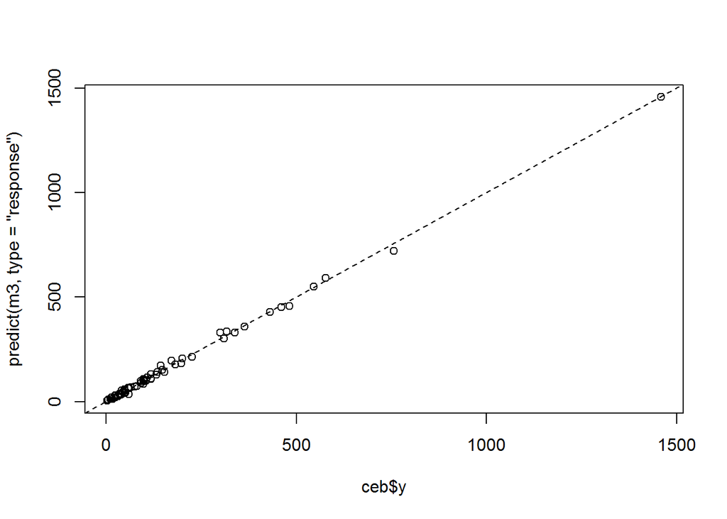

```r
plot(ceb$y,predict(m3,type="response"))  # Comparativa de la resposta versus el comptatge
abline(0,1,lty=2)
```

```r
cbind(pr,ceb$y) # Valors esperats y realització d¡una poison per a cada una de les lambdas. [,1] Taxa resultant de multiplicar el predictor per n y [,2]el valor esperat de fills.
```

```
##            pr
## 1   31.683227    4
## 2   83.168472   24
## 3  166.336944   38
## 4  201.980575   37
## 5   47.524841   14
## 6  106.930893   23
## 7  154.455734   41
## 8  201.980575   35
## 9  245.545013   60
## 10 403.961151   98
## 11 423.763168  104
## 12 186.138962   35
## 13  39.604034   31
## 14 118.812103   80
```

[output cut: 56 more lines]

```r
Anova(m3)
```

```
## Analysis of Deviance Table (Type II tests)
##
## Response: y
##      LR Chisq Df Pr(>Chisq)
## dur   2575.82  5  < 2.2e-16 ***
## res     29.53  2  3.876e-07 ***
## educ    50.02  3  7.930e-11 ***
## ---
## Signif. codes:  0 '***' 0.001 '**' 0.01 '*' 0.05 '.' 0.1 ' ' 1
```

Si vull saber el nombre esperat de fills per dona, per a una dona amb unes altres característiques, hauriem d’anar tenint en compte els coeficients dels altres parámetres, en funció de la durada del matrimoni que tingui etc.